# Week 4 lab practice

# General instructions

To answer the questions in this practice sheet:

1. Open `week-4-practice.R` located in the `code/` sub-folder and set the **working directory** to its location. In RStudio,

   ```
   Session > Set Working Directory > To Source File Location
   ```

2. Apply the code you saw in the demonstration scripts and pre-recorded demonstration videos to answer the questions below.

During this lab session, you will write R code to answer questions on data analysis topics you have seen in the main lectures and the demonstration videos. By completing the tasks in this document, **you will practice**:

- practice prediction,
- cross-validation,
- multiple imputation.

You will need the following **datasets**:

- `yps.rds`
- `bfiANC2.rds`

which are located in the `data/` sub-folder of the `week-4-lab` folder.

# 1 Preliminaries

## 1.1 - Load the `MLmetrics` and `mice` packages.

```r
# Load packages
library(MLmetrics)
library(mice)
```

## 1.2 - Source the `custom-functions.R` script (use `source`).

```r
# Source functions
source("custom-functions.R")
```

**Tip**: If this is returning an error, remember to check your working directory!

## 1.3 - Load the `yps.rds` and `bfiANC2.rds` datasets into your workspace.

```r
# Load data
dataDir <- "../data/"
yps <- readRDS(paste0(dataDir, "yps.rds"))
bfiANC2 <- readRDS(paste0(dataDir, "bfiANC2.rds"))
```

# 2 Split-Sample CV (Simple Split)

Use the `yps.rds` data to answer the questions in this section.

## 2.1 - Randomly split the sample into disjoint training and testing sets

Make sure to:

- **Set the seed** to 235711 so that all of us can get the same results.
- Use 800 and 210 as sample sizes for the training and test data, respectively.

You can use the code below to get started:

```r
# Set the random seed
set.seed(235711)

# Create a vector to assign observations to a training and testing set
ind <- sample(c(rep("train", 800), rep("test", 210)))

# Assign rows of the data to the training and testing sets
tmp <- split(yps, ind)

# Create data.frames for the training and test sets
train <- tmp$train
test <- tmp$test
```

## 2.2 - Estimate a baseline model on the training data.

Regress `Number.of.friends` onto:

- `Age`
- `Sex`

```r
# Fit the baseline model
lm0 <- lm(Number.of.friends ~ Age + Sex, data = train)
```

## 2.3 - Update the baseline model from 2.2

**Tip**: Store the results in new objects (e.g., `lm0`, `lm1`, etc.)

```r
# Update the baseline model using the update function
lm1 <- update(lm0, ". ~ . + Keeping.promises + Empathy + Friends.versus.money + Charity")
```

## 2.4 - Update the baseline model from 2.2

Add the following variables as predictors:

- `Branded.clothing`
- `Entertainment.spending`
- `Spending.on.looks`
- `Spending.on.gadgets`

```r
# Update the baseline model using the update function
lm2 <- update(lm0, ". ~ . + Branded.clothing + Entertainment.spending + Spending.on.looks + Spending.on.gadgets")
```

## 2.5 - Update the baseline model from 2.2

Add the following variables as predictors:

- `Workaholism`
- `Reliability`
- `Responding.to.a.serious.letter`
- `Assertiveness`

```r
# Update the baseline model using the update function
lm3 <- update(lm0, ". ~ . + Workaholism + Reliability + Responding.to.a.serious.letter + Assertiveness")
```

## 2.6 - Compute training-set predictions from the models estimated in 2.3, 2.4, and 2.5.

```r
# Use the predict function to obtain prediction from each model
p1 <- predict(lm1)
p2 <- predict(lm2)
p3 <- predict(lm3)
```

## 2.7 - Compute training-set MSEs for the models estimated in 2.3, 2.4, and 2.5.

```r
# Use the MSE function from the MLmetric package to compute the training MSE
mse1 <- MSE(
     y_pred = p1, # predicted values based on our model
     y_true = train$Number.of.friends # true values of the DV in the training data
)
mse2 <- MSE(y_pred = p2, y_true = train$Number.of.friends)
mse3 <- MSE(y_pred = p3, y_true = train$Number.of.friends)
```

## 2.8 - Compute test-set predictions from the models estimated in 2.3, 2.4, and 2.5.

```r
# Use the predict function to obtain predictions on the test data from each model
p1.2 <- predict(
     object = lm1, # model we are using to obtain predictions
     newdata = test # data on which predictions are obtained
)
p2.2 <- predict(lm2, newdata = test)
p3.2 <- predict(lm3, newdata = test)
```

## 2.9 - Compute test-set MSEs for the three models you estimated in 2.3, 2.4, and 2.5.

```r
# Use the MSE function from the MLmetric package to compute the test MSE
mse1.2 <- MSE(
     y_pred = p1.2, # predicted (test-set) values based on our model
     y_true = test$Number.of.friend # true values of the DV in the test(!) data
)
mse2.2 <- MSE(y_pred = p2.2, y_true = test$Number.of.friend)
mse3.2 <- MSE(y_pred = p3.2, y_true = test$Number.of.friend)
```

## 2.10 - Which model should be preferred based on the training-set prediction error?

Compare the models estimated in 2.3, 2.4, and 2.5 based on their relative *training-set* prediction errors.

```r
# Store the training MSEs in a single vector
mse <- c(mse1, mse2, mse3)

# Look at it
mse
```

```
[1] 1.072075 1.032522 1.070400
```

```r
# Ask R to return the smallest value in the vector
min(mse)
```

```
[1] 1.032522
```

```r
# Ask R to return the index of the smallest value in the vector
which.min(mse)
```

```
[1] 2
```

## 2.11 - Which model should be preferred based on the test-set prediction error?

Compare the models estimated in 2.3, 2.4, and 2.5 based on their relative *test-set* prediction errors.

```r
# Store the training MSEs in a single vector
mse.2 <- c(mse1.2, mse2.2, mse3.2)

# Look at it
mse.2
```

```
[1] 1.0058827 0.9590419 1.0827909
```

```r
# Ask R to return the smallest value in the vector
min(mse.2)
```

```
[1] 0.9590419
```

```r
# Ask R to return the index of the smallest value in the vector
which.min(mse.2)
```

```
[1] 2
```

# 3 Split-sample CV (3-way)

## 3.1 - Randomly split the sample into disjoint training, validation, and testing sets.

Make sure to:

- **Set the seed** to 235711 so that all of us can get the same results.
- Use 700, 155, and 155 as sample sizes for the training, validation, and test data, respectively.

You can use the code below to get started:

```r
# Set the random seed
set.seed(235711)

# Create an index to split the data according to what was requested
ind <- sample(c(rep("train", 700), rep("valid", 155), rep("test", 155)))

# Split the data based on the index you just created
yps2 <- split(yps, ind)

# Store the data sets with simple names
train <- yps2$train
valid <- yps2$valid
test <- yps2$test
```

## 3.2 - Re-estimate the models from 2.3, 2.4, and 2.5 on the training data from 3.1

```r
# Estiamte the models on a different dataset
lm1.2 <- update(lm1, data = train)
lm2.2 <- update(lm2, data = train)
lm3.2 <- update(lm3, data = train)
```

## 3.3 - Compute the validation-set predictions from the three models you estimated in 3.2.

```r
# Use the predict function to obtain predictions on the validation set
p1.vali <- predict(
     object = lm1.2, # model estimated on training data
     newdata = valid # VALIDATION!
)
p2.vali <- predict(lm2.2, newdata = valid)
p3.vali <- predict(lm3.2, newdata = valid)
```

## 3.4 - Compute the validation-set MSEs for the three models you estimated in 3.2.

```r
# Use the MSE function from the MLmetric package to compute the validation-set MSEs
mse1.vali <- MSE(y_pred = p1.vali, y_true = valid$Number.of.friend)
mse2.vali <- MSE(y_pred = p2.vali, y_true = valid$Number.of.friend)
mse3.vali <- MSE(y_pred = p3.vali, y_true = valid$Number.of.friend)
```

## 3.5 - Which model should be preferred based on the validation-set prediction error?

Compare the models estimated in 3.2 based on their relative prediction errors in the validation set.

```r
# Store the validation MSEs in a single vector
mse.vali <- c(mse1.vali, mse2.vali, mse3.vali)

# Look at it
mse.vali
```

```
[1] 1.084637 1.118788 1.083258
```

```r
# Print a response to the question
paste("I would choose model", which.min(mse.vali))
```

```
[1] "I would choose model 3"
```

## 3.6 - Re-estimate the chosen model in 3.5 using the combined training and validation data.

```r
# Update the chosen model by estimating it again on a larger dataset
lm3.3 <- update(
     object = lm3.2, # chosen model
     data = rbind(train, valid) # combination of training and validation data sets
)
```

## 3.7 - Estimate the prediction error for the model estimated in 3.6.

Use the testing data that you set aside in 3.1 to estimate the prediction error (i.e., test set MSE) of the updated chosen model from 3.6.

```r
# Compute the predictions on the test data with the re-estimated chosen model
p3.test <- predict(lm3.3, newdata = test)

# Use the MSE function to obtain the estimate of the prediction error
MSE(
     y_pred = p3.test,
     y_true = test$Number.of.friend # TEST SET!
)
```

```
[1] 1.085043
```

# 4 K-Fold Cross-Validation

Use the `yps` data to answer the questions in this section.

## 4.1 - Randomly split the sample into disjoint training and testing sets

Make sure to:

- **Set the seed** to 235711 so that all of us can get the same results.
- Use 800 and 210 as sample sizes for the training and test data, respectively.

You can use the code below:

```r
# Set the random seed
set.seed(235711)

# Create the index for splitting the data
index <- sample(c(rep("train", 800), rep("test", 210)))

# Use the split function to split data as requested
yps2 <- split(yps, index)

# Store objects with easy names
train <- yps2$train
test <- yps2$test
```

## 4.2 - Use the training data from 4.1 to run 5-fold cross-validation comparing the following three models:

- A model regressing `Number.of.friends` onto:
  - `Age`
  - `Sex`
  - `Keeping.promises`
  - `Empathy`
  - `Friends.versus.money`
  - `Charity`
- A model regressing `Number.of.friends` onto:
  - `Age`
  - `Sex`
  - `Branded.clothing`
  - `Entertainment.spending`
  - `Spending.on.looks`
  - `Spending.on.gadgets`
- A model regressing `Number.of.friends` onto:
  - `Age`
  - `Sex`
  - `Workaholism`
  - `Reliability`
  - `Responding.to.a.serious.letter`
  - `Assertiveness`

You can use the following code to get started:

```r
# Define a vector containing the formulas for the requested models
models <- c(
     "Number.of.friends ~ Age + Sex + Keeping.promises + Empathy + Friends.versus.money + Charity",
     "Number.of.friends ~ Age + Sex + Branded.clothing + Entertainment.spending + Spending.on.looks + Spending.on.gadgets",
     "Number.of.friends ~ Age + Sex + Workaholism + Reliability + Responding.to.a.serious.letter + Assertiveness"
)
```

To perform the cross-validation use the `cv.lm()` function you have seen in the `week-4-demo-1.R` script. Use `seed = 235711` inside the function.

```r
# Perform the cross-validation with the cv.lm() function
cve <- cv.lm(
     data = train, # which data are we using for the K-fold CV?
     models = models, # which models are we comparing?
     K = 5, # how many folds?
     seed = 235711 # requested seed?
)
```

## 4.3 - Which model should be preferred based on the relative cross-validation errors computed in 4.2?

```r
# Print the vector of cross-validation errors
cve
```

```
                        Number.of.friends ~ Age + Sex + Keeping.promises + Empathy + Friends.versus.money + Charity
                                                                                                           1.097686
Number.of.friends ~ Age + Sex + Branded.clothing + Entertainment.spending + Spending.on.looks + Spending.on.gadgets
                                                                                                           1.051242
         Number.of.friends ~ Age + Sex + Workaholism + Reliability + Responding.to.a.serious.letter + Assertiveness
                                                                                                           1.084396
```

```r
# And return the smallest one
cve[which.min(cve)]
```

```
Number.of.friends ~ Age + Sex + Branded.clothing + Entertainment.spending + Spending.on.looks + Spending.on.gadgets
                                                                                                           1.051242
```

## 4.4 - Estimate the prediction error for the model chosen in 4.3.

Use the testing data that you set aside in 4.1 to estimate the prediction error (i.e., test set MSE) of the model chosen in 4.3.

```r
# Train the selected model on the training data
lm.kcv.train <- lm(models[which.min(cve)], data = train)

# Use the MSE function on the test data
MSE(
     y_pred = predict(lm.kcv.train, newdata = test),
     y_true = test$Number.of.friends
)
```

```
[1] 0.9590419
```

# 5 Multiple Imputation

Use the `bfiANC2` data to answer the questions in this section.

## 5.1 - Use the `mice` package, with the following setup, to create multiple imputations of the `bfiANC2` data.

- 25 imputations
- 15 iterations
- A random number seed of `314159`
- All `A` variables imputed with predictive mean matching
- All `C` variables imputed with linear regression using bootstrapping
- All `N` variables imputed with Bayesian linear regression
- The `education` variable imputed with polytomous logistic regression
- A predictor matrix generated with the `quickpred` function using the following setup:
  - The minimum correlation set to 0.25
  - The `age` and `sex` variables included in all elementary imputation models
  - The `id` variable excluded from all elementary imputation models

**Tips**:

- start with defining your own method vector (e.g., `meth`) and the predictor matrix (e.g., `predMat`);
- use the help functions `?mice` and `?quickpred` to know more about which arguments to use (e.g., the built-in imputation methods).

```r
# Check the column names:
meth <- rep("", ncol(bfiANC2))
names(meth) <- colnames(bfiANC2)

# Define our own method vector:
meth[2:6] <- rep("pmm", 5)
meth[7:11] <- rep("norm.boot", 5)
meth[12:16] <- rep("norm", 5)
meth["education"] <- "polyreg"

# Or fancy way
meth <- rep("", ncol(bfiANC2))
names(meth) <- colnames(bfiANC2)

meth[grep("^A\\d", names(meth))] <- "pmm"
meth[grep("^N\\d", names(meth))] <- "norm"
meth[grep("^C\\d", names(meth))] <- "norm.boot"
meth["education"] <- "polyreg"

# Check the method vector:
meth
```

```
         id          A1          A2          A3          A4          A5          C1          C2
         ""       "pmm"       "pmm"       "pmm"       "pmm"       "pmm" "norm.boot" "norm.boot"
         C3          C4          C5          N1          N2          N3          N4          N5
"norm.boot" "norm.boot" "norm.boot"      "norm"      "norm"      "norm"      "norm"      "norm"
        sex   education         age
         ""   "polyreg"          ""
```

```r
# Use mice::quickpred to generate a predictor matrix:
predMat <- quickpred(
     data = bfiANC2,
     mincor = 0.25,
     include = c("age", "sex"),
     exclude = "id"
)

# Check the predictor matrix:
predMat
```

```
          id A1 A2 A3 A4 A5 C1 C2 C3 C4 C5 N1 N2 N3 N4 N5 sex education age
id         0  0  0  0  0  0  0  0  0  0  0  0  0  0  0  0   0         0   0
A1         0  0  1  1  0  0  0  0  0  0  0  0  0  0  0  0   1         0   1
A2         0  1  0  1  1  1  0  0  0  0  0  0  0  0  0  0   1         0   1
A3         0  1  1  0  1  1  0  0  0  0  0  0  0  0  0  0   1         0   1
A4         0  0  1  1  0  1  0  1  0  0  0  0  0  0  0  0   1         0   1
A5         0  0  1  1  1  0  0  0  0  0  0  0  0  0  0  0   1         0   1
C1         0  0  0  0  0  0  0  1  1  1  0  0  0  0  0  0   1         0   1
C2         0  0  0  0  1  0  1  0  1  1  1  0  0  0  0  0   1         0   1
C3         0  0  0  0  0  0  1  1  0  1  1  0  0  0  0  0   1         0   1
C4         0  0  0  0  0  0  1  1  1  0  1  1  0  1  0  0   1         0   1
C5         0  0  0  0  0  0  0  1  1  1  0  0  1  1  1  0   1         0   1
N1         0  0  0  0  0  0  0  0  0  1  0  0  1  1  1  1   1         0   1
N2         0  0  0  0  0  0  0  0  0  0  1  1  0  1  1  1   1         0   1
N3         0  0  0  0  0  0  0  0  0  1  1  1  1  0  1  1   1         0   1
N4         0  0  0  0  0  0  0  0  0  0  1  1  1  1  0  1   1         0   1
N5         0  0  0  0  0  0  0  0  0  0  0  1  1  1  1  0   1         0   1
sex        0  0  0  0  0  0  0  0  0  0  0  0  0  0  0  0   0         0   0
education  0  0  0  0  1  0  0  0  0  0  0  0  0  0  0  0   1         0   1
age        0  0  0  0  0  0  0  0  0  0  0  0  0  0  0  0   0         0   0
```

```r
# Impute missing using the method vector from above:
miceOut1 <- mice(
     data = bfiANC2,
     m = 25, # number of imputations
     maxit = 15, # number of iterations
     predictorMatrix = predMat, # custom specified version
     method = meth, # custom imputation method vector
     printFlag = FALSE, # just to hide the output in the console
     seed = 314159 # desired seed
)
```

## 5.2 - Create trace plots of the imputed values’ means and SDs to check that the imputation models converged.

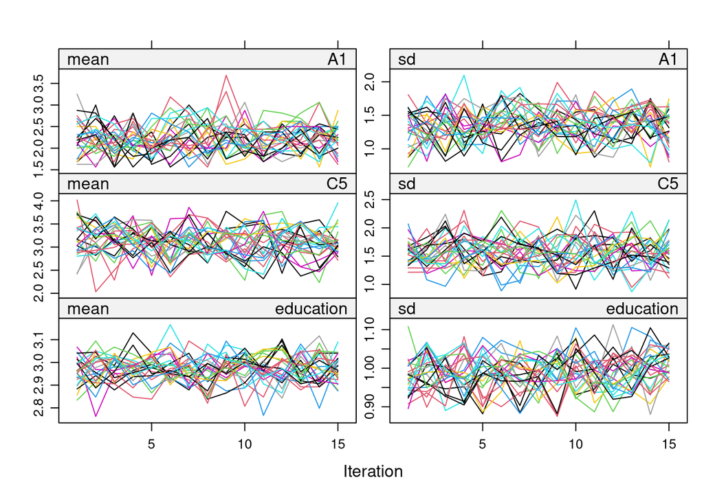

```r
# Make trace plots for a few variables at the time
plot(miceOut1, c("A1", "C5", "education"))
```

```r
# Or for all variables (not shown here)
plot(miceOut1)
```

## 5.3 - Create overlaid density plots of the imputed vs. observed values to sanity-check the imputations.

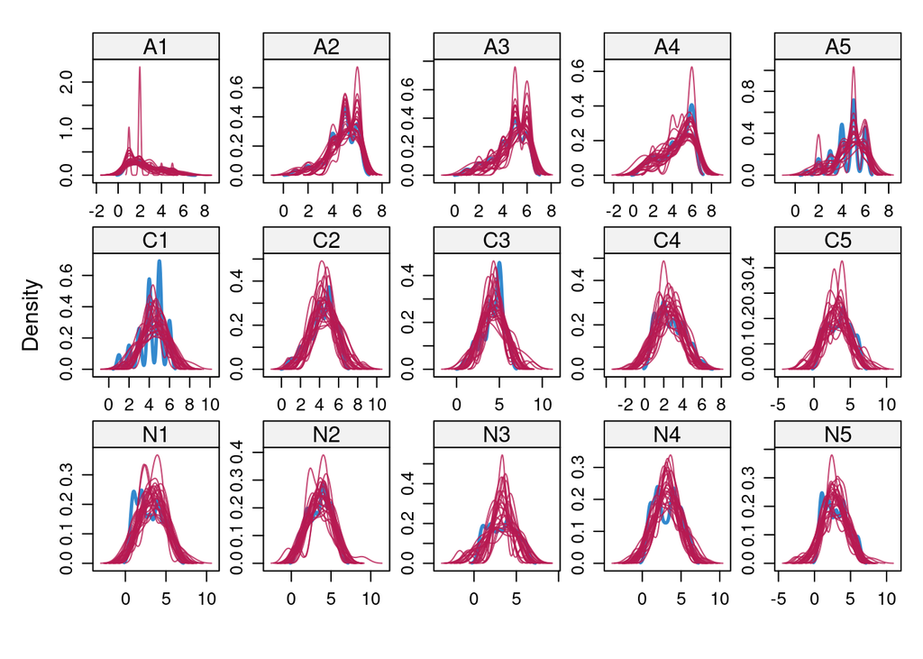

```r
# Make density plots
densityplot(miceOut1)
```

## 5.4 - Based on the plots you created in 5.2 and 5.3, would you say that the imputations are valid?

Yes. The imputation models look to have converged and the imputed values seem reasonable.

## 5.5 - Regress `A1` onto `C1`, `N1`, and `education` using the multiply imputed data from 5.1

**Tip**: Use the `with()` function and the `mids` object

```r
# Fit the same model to all imputed data sets using the `with()` the approach
fits1 <- with(miceOut1, lm(A1 ~ C1 + N1 + education))
```

## 5.6 - Regress `A1` onto `C1`, `N1`, `education` `age`, and `sex` using the multiply imputed data from 5.1

```r
# Fit a new model to all imputed data sets
fits2 <- with(miceOut1, lm(A1 ~ C1 + N1 + education + age + sex))
```

## 5.7 - What is the MI estimate of the slope of `age` on `A1` from 5.6?

```r
# Pool coefficient estimates
poolFit2 <- pool(fits2)

# Check output
summary(poolFit2)
```

```
                      term    estimate   std.error  statistic        df      p.value
1              (Intercept)  2.54241889 0.363439056  6.9954477 272.72443 2.044253e-11
2                       C1  0.12296558 0.046122677  2.6660548 508.31482 7.919095e-03
3                       N1  0.16911956 0.038163035  4.4315018 491.76521 1.154707e-05
4         educationhs grad  0.21751318 0.349234268  0.6228288  97.50133 5.348511e-01
5    educationsome college -0.17726743 0.258503781 -0.6857440 122.19441 4.941735e-01
6    educationcollege grad -0.22704111 0.325124793 -0.6983199 113.14877 4.864099e-01
7 educationgraduate degree -0.27091280 0.326861657 -0.8288302 108.98923 4.090120e-01
8                      age -0.02188277 0.005256538 -4.1629615 464.40608 3.744948e-05
9                sexfemale -0.40403072 0.126593151 -3.1915685 535.75798 1.497987e-03
```

```r
# Extract the slope of interest
tmp <- poolFit2$pooled[poolFit2$pooled == "age", ]
tmp["estimate"]
```

```
     estimate
8 -0.02188277
```

## 5.8 - Is the partial effect of `age` from 5.6 significant at the $\alpha$ level 0.05?

```r
# Compute the t-statistic:
tStat <- with(tmp, estimate / sqrt(t))

# Compute the p-value (or read it from the summary)
pVal <- 2 * pt(q = abs(tStat), df = tmp$df, lower.tail = FALSE)

# Check with an ifelse
ifelse(pVal < 0.05, "YES", "NO")
```

```
[1] "YES"
```

## 5.9 - What is the MI estimate of the $R^2$ from the model in 5.5?

```r
# Pool the R2 properly
r2.1 <- pool.r.squared(fits1)[, "est"]

# And print the value
r2.1
```

```
[1] 0.06339168
```

## 5.10 - What is the MI estimate of the $R^2$ from the model in 5.6?

```r
# Pool the R2 properly
r2.2 <- pool.r.squared(fits2)[, "est"]

# And print the value
r2.2
```

```
[1] 0.1130129
```

## 5.11 - What is the MI estimate of the increase in $R^2$ when going from the model in 5.5 to the model in 5.6?

```r
# Compute the difference in R2
r2.2 - r2.1
```

```
[1] 0.04962119
```

## 5.12 - Is the increase in $R^2$ from 5.11 statistically significant at the $\alpha$ level 0.05?

```r
# Do an F-test for the increase in R^2:
out6b <- D1(fits2, fits1)

# Check with an ifelse if the Pvalue is less than .05
ifelse(out6b$result[, "P(>F)"] < 0.05, "YES", "NO")
```

```
P(>F)
"YES"
```

## 5.13 - What is the value of the test statistic that you used to answer 5.12?

```r
# Exctract the F statistic that was used
out6b$result[, "F.value"]
```

```
 F.value
14.72923
```

# 6 TL;DR, just give me the code!

```r
# Load packages
library(MLmetrics)
library(mice)
# Source functions
source("custom-functions.R")
# Load data
dataDir <- "../data/"
yps <- readRDS(paste0(dataDir, "yps.rds"))
bfiANC2 <- readRDS(paste0(dataDir, "bfiANC2.rds"))
# Set the random seed
set.seed(235711)

# Create a vector to assign observations to a training and testing set
ind <- sample(c(rep("train", 800), rep("test", 210)))

# Assign rows of the data to the training and testing sets
tmp <- split(yps, ind)

# Create data.frames for the training and test sets
train <- tmp$train
test <- tmp$test
# Fit the baseline model
lm0 <- lm(Number.of.friends ~ Age + Sex, data = train)
# Update the baseline model using the update function
lm1 <- update(lm0, ". ~ . + Keeping.promises + Empathy + Friends.versus.money + Charity")
# Update the baseline model using the update function
lm2 <- update(lm0, ". ~ . + Branded.clothing + Entertainment.spending + Spending.on.looks + Spending.on.gadgets")
# Update the baseline model using the update function
lm3 <- update(lm0, ". ~ . + Workaholism + Reliability + Responding.to.a.serious.letter + Assertiveness")
# Use the predict function to obtain prediction from each model
p1 <- predict(lm1)
p2 <- predict(lm2)
p3 <- predict(lm3)
# Use the MSE function from the MLmetric package to compute the training MSE
mse1 <- MSE(
     y_pred = p1, # predicted values based on our model
     y_true = train$Number.of.friends # true values of the DV in the training data
)
mse2 <- MSE(y_pred = p2, y_true = train$Number.of.friends)
mse3 <- MSE(y_pred = p3, y_true = train$Number.of.friends)
# Use the predict function to obtain predictions on the test data from each model
p1.2 <- predict(
     object = lm1, # model we are using to obtain predictions
     newdata = test # data on which predictions are obtained
)
p2.2 <- predict(lm2, newdata = test)
p3.2 <- predict(lm3, newdata = test)
# Use the MSE function from the MLmetric package to compute the test MSE
mse1.2 <- MSE(
     y_pred = p1.2, # predicted (test-set) values based on our model
     y_true = test$Number.of.friend # true values of the DV in the test(!) data
)
mse2.2 <- MSE(y_pred = p2.2, y_true = test$Number.of.friend)
mse3.2 <- MSE(y_pred = p3.2, y_true = test$Number.of.friend)
# Store the training MSEs in a single vector
mse <- c(mse1, mse2, mse3)

# Look at it
mse

# Ask R to return the smallest value in the vector
min(mse)

# Ask R to return the index of the smallest value in the vector
which.min(mse)
# Store the training MSEs in a single vector
mse.2 <- c(mse1.2, mse2.2, mse3.2)

# Look at it
mse.2

# Ask R to return the smallest value in the vector
min(mse.2)

# Ask R to return the index of the smallest value in the vector
which.min(mse.2)
# Set the random seed
set.seed(235711)

# Create an index to split the data according to what was requested
ind <- sample(c(rep("train", 700), rep("valid", 155), rep("test", 155)))

# Split the data based on the index you just created
yps2 <- split(yps, ind)

# Store the data sets with simple names
train <- yps2$train
valid <- yps2$valid
test <- yps2$test
# Estiamte the models on a different dataset
lm1.2 <- update(lm1, data = train)
lm2.2 <- update(lm2, data = train)
lm3.2 <- update(lm3, data = train)
# Use the predict function to obtain predictions on the validation set
p1.vali <- predict(
     object = lm1.2, # model estimated on training data
     newdata = valid # VALIDATION!
)
p2.vali <- predict(lm2.2, newdata = valid)
p3.vali <- predict(lm3.2, newdata = valid)
# Use the MSE function from the MLmetric package to compute the validation-set MSEs
mse1.vali <- MSE(y_pred = p1.vali, y_true = valid$Number.of.friend)
mse2.vali <- MSE(y_pred = p2.vali, y_true = valid$Number.of.friend)
mse3.vali <- MSE(y_pred = p3.vali, y_true = valid$Number.of.friend)
# Store the validation MSEs in a single vector
mse.vali <- c(mse1.vali, mse2.vali, mse3.vali)

# Look at it
mse.vali

# Print a response to the question
paste("I would choose model", which.min(mse.vali))
# Update the chosen model by estimating it again on a larger dataset
lm3.3 <- update(
     object = lm3.2, # chosen model
     data = rbind(train, valid) # combination of training and validation data sets
)
# Compute the predictions on the test data with the re-estimated chosen model
p3.test <- predict(lm3.3, newdata = test)

# Use the MSE function to obtain the estimate of the prediction error
MSE(
     y_pred = p3.test,
     y_true = test$Number.of.friend # TEST SET!
)
# Set the random seed
set.seed(235711)

# Create the index for splitting the data
index <- sample(c(rep("train", 800), rep("test", 210)))

# Use the split function to split data as requested
yps2 <- split(yps, index)

# Store objects with easy names
train <- yps2$train
test <- yps2$test
# Define a vector containing the formulas for the requested models
models <- c(
     "Number.of.friends ~ Age + Sex + Keeping.promises + Empathy + Friends.versus.money + Charity",
     "Number.of.friends ~ Age + Sex + Branded.clothing + Entertainment.spending + Spending.on.looks + Spending.on.gadgets",
     "Number.of.friends ~ Age + Sex + Workaholism + Reliability + Responding.to.a.serious.letter + Assertiveness"
)
# Perform the cross-validation with the cv.lm() function
cve <- cv.lm(
     data = train, # which data are we using for the K-fold CV?
     models = models, # which models are we comparing?
     K = 5, # how many folds?
     seed = 235711 # requested seed?
)
# Print the vector of cross-validation errors
cve

# And return the smallest one
cve[which.min(cve)]
# Train the selected model on the training data
lm.kcv.train <- lm(models[which.min(cve)], data = train)

# Use the MSE function on the test data
MSE(
     y_pred = predict(lm.kcv.train, newdata = test),
     y_true = test$Number.of.friends
)
# Check the column names:
meth <- rep("", ncol(bfiANC2))
names(meth) <- colnames(bfiANC2)

# Define our own method vector:
meth[2:6] <- rep("pmm", 5)
meth[7:11] <- rep("norm.boot", 5)
meth[12:16] <- rep("norm", 5)
meth["education"] <- "polyreg"

# Or fancy way
meth <- rep("", ncol(bfiANC2))
names(meth) <- colnames(bfiANC2)

meth[grep("^A\\d", names(meth))] <- "pmm"
meth[grep("^N\\d", names(meth))] <- "norm"
meth[grep("^C\\d", names(meth))] <- "norm.boot"
meth["education"] <- "polyreg"

# Check the method vector:
meth

# Use mice::quickpred to generate a predictor matrix:
predMat <- quickpred(
     data = bfiANC2,
     mincor = 0.25,
     include = c("age", "sex"),
     exclude = "id"
)

# Check the predictor matrix:
predMat

# Impute missing using the method vector from above:
miceOut1 <- mice(
     data = bfiANC2,
     m = 25, # number of imputations
     maxit = 15, # number of iterations
     predictorMatrix = predMat, # custom specified version
     method = meth, # custom imputation method vector
     printFlag = FALSE, # just to hide the output in the console
     seed = 314159 # desired seed
)
# Make trace plots for a few variables at the time
plot(miceOut1, c("A1", "C5", "education"))
# Or for all variables (not shown here)
plot(miceOut1)
# Make density plots
densityplot(miceOut1)
cat(
     "Yes. The imputation models look to have converged and the imputed values seem reasonable."
)
# Fit the same model to all imputed data sets using the `with()` the approach
fits1 <- with(miceOut1, lm(A1 ~ C1 + N1 + education))
# Fit a new model to all imputed data sets
fits2 <- with(miceOut1, lm(A1 ~ C1 + N1 + education + age + sex))
# Pool coefficient estimates
poolFit2 <- pool(fits2)

# Check output
summary(poolFit2)

# Extract the slope of interest
tmp <- poolFit2$pooled[poolFit2$pooled == "age", ]
tmp["estimate"]
# Compute the t-statistic:
tStat <- with(tmp, estimate / sqrt(t))

# Compute the p-value (or read it from the summary)
pVal <- 2 * pt(q = abs(tStat), df = tmp$df, lower.tail = FALSE)

# Check with an ifelse
ifelse(pVal < 0.05, "YES", "NO")
# Pool the R2 properly
r2.1 <- pool.r.squared(fits1)[, "est"]

# And print the value
r2.1
# Pool the R2 properly
r2.2 <- pool.r.squared(fits2)[, "est"]

# And print the value
r2.2
# Compute the difference in R2
r2.2 - r2.1
# Do an F-test for the increase in R^2:
out6b <- D1(fits2, fits1)

# Check with an ifelse if the Pvalue is less than .05
ifelse(out6b$result[, "P(>F)"] < 0.05, "YES", "NO")
# Exctract the F statistic that was used
out6b$result[, "F.value"]
```